# TableMt_2012

D. Ackerly, J. Slingsby

February 14, 2016

See intro material in TableMt_2012_daily

The goal of this script is to see if sites differ in their temperature sensitivity relative to variation in regional temperature. In other words, does temperature increase more in some sites than others, relative to mean conditions on the landscape. The method I’m using here is to plot daily temp (min, max, T06, T14) for each site vs. the average across all sites, and then calculate the slope of this relationship. A slope = 1 would mean that temperatures at a site vary exactly in sync with regional temperature. Slope > 1 would be a site that warms up more on hot days and cools down more on coold days, and slope < 1 would be buffered, warming up less and cooling less. The intercept would also matter. A slope > 1 with an intercept above the average line would be a site that is hot in general, but still cools and heats more than the landscape as a whole.

This analysis could also be done using the delta of each site relative to the regional mean, and then slope = 0 would be a coupled site, and slopes >0 and <0 would represent more or less sensitive sites.

Here’s an example for T06 - temperature at 6am.

```r
#----------------#
# LOAD LIBRARIES #
#----------------#
rm(list=ls())
library(raster)
library(RColorBrewer)
```

‘meta’ contains metadata on the 96 sites. ‘topo10’ and ‘topo30’ have a series of topographic features sampled from 10m and 30m dem rasters, respectively, based on lat/long positions of each site. SiteID is the unique name for each site.

Some of the variables in ‘meta’: * elevation, slope, and aspect: measured in the field - these are generally not used, and instead we use a consistent set of values taken from the 10m dem. * use4Analyses, use4ClimateSummaries: sites excluded due to incomplete data (see ms for criteria)

Variables in topo10 and topo30: * d2at, d2fb, d2cs: distance to atlantic, distance to false bay, distance to coast = min(d2at,d2fb) * rad080, rad172, rad355: solar radiation at summer and winter solstice, and equinox. Not generally used as we have diurnal radiation at each site * thl0, thl315, thl337: Topographic heat load as defined by McCune and Keon 2002 JVS, with the axis for calculation of the ‘folded aspect’ (and thus the maximum heat load) at 0, 337 or 315 degrees. The logic is that in the S Hem, NW facing slopes would be hotter than N facing, due to higher afternoon temperatures. * plow050, 125, 250, 500: Percent lower pixels - the percent of pixels surrounding a focal pixel with a lower elevation, in radii of 50, 125, 250 or 500 m. A measure of potential for cold air to flow away from a spot. Higher values indicate hilltops * tpi050, 125, 250, 500: Elevation of a focal pixel - mean elevation in the specified radius. Another measure of hillslope position, with positive values for hilltops, negative for valley bottoms.

```r
#----------------#
# LOAD DATA      #
#----------------#
meta <- read.csv('data/csv_masters/location_meta.csv',as.is=T)
dim(meta)
```

```
## [1] 96 27
```

```r
head(meta)
```

```
##       domain siteID   logger UTM.east UTM.north   LON_DD    LAT_DD
## 1 SILVERMINE   CHK1 10008095   256907   6228779 18.36633 -34.05353
## 2 SILVERMINE   CHK2 10006349   257070   6229153 18.36820 -34.05020
## 3 SILVERMINE   CHK3 10008094   257271   6228903 18.37031 -34.05250
## 4 SILVERMINE   CHK4 10008096   257420   6229224 18.37201 -34.04964
## 5 SILVERMINE   CHK5 10008093   258353   6229582 18.38221 -34.04663
## 6 SILVERMINE   CHK6 10006348   258397   6229772 18.38274 -34.04493
##   elevation slope_deg aspect_deg magn.true.aspect use4Analyses
## 1       120        19        265                M            1
## 2       326         8        350                M            1
## 3       325        32        240                M            1
## 4       367        26        355                M            1
## 5       436        35         15                M            1
## 6       455        33        280                M            1
##   use4ClimateSummaries route CollSeq series deployed.as deployXssn
```

[output cut: 20 more lines]

```r
topo10 <- read.csv('data/csv_masters/topo10.csv',as.is=T)
dim(topo10)
```

```
## [1] 96 22
```

```r
names(topo10)
```

```
##  [1] "siteID"    "domain"    "elevation" "slope"     "aspect"
##  [6] "d2at"      "d2fb"      "d2cs"      "rad080"    "rad172"
## [11] "rad355"    "thl0"      "thl315"    "thl337"    "plow050"
## [16] "plow125"   "plow250"   "plow500"   "tpi050"    "tpi125"
## [21] "tpi250"    "tpi500"
```

```r
topo30 <- read.csv('data/csv_masters/topo30.csv',as.is=T)
dim(topo30)
```

```
## [1] 96 21
```

```r
names(topo30)
```

```
##  [1] "siteID"    "domain"    "elevation" "slope"     "d2at"
##  [6] "d2fb"      "d2cs"      "rad080"    "rad172"    "rad355"
## [11] "thl0"      "thl315"    "thl337"    "plow050"   "plow125"
## [16] "plow250"   "plow500"   "tpi050"    "tpi125"    "tpi250"
## [21] "tpi500"
```

‘dw’ has all daily weather values for all sites and days. The dlySummary contains summaries of weather data on each day - average weather across sites. dlySol has diurnal radiation at each site for each day of the year, from Adam Wilson’s analyses on a 30m dem.

```r
dw <- read.csv('data/csv_masters/2012daily.csv',as.is=T)
dw$doy <- dw$doy11 - 365
head(dw)
```

```
##   doy11 year month day   Tmin Tmin.time   Tmax Tmax.time   Tmean  RHmin
## 1   366 2012     1   1 14.936  6.166667 25.210  17.16667 20.0730 71.361
## 2   366 2012     1   1 13.762  6.166667 27.161  15.00000 20.4615 78.299
## 3   366 2012     1   1 13.233  6.000000 22.776  17.33333 18.0045 83.567
## 4   366 2012     1   1 13.546  6.000000 25.647  15.33333 19.5965 81.918
## 5   366 2012     1   1 12.413  6.000000 22.896  13.83333 17.6545 91.167
## 6   366 2012     1   1 12.727  6.000000 27.014  14.00000 19.8705 84.421
##    RHmax    VPmax RHsat.hrs     date siteID doy    T06    T14
## 1 77.590 2.239716         0 2012-1-1   CHK1   1 14.984 24.968
## 2 82.556 2.267693         0 2012-1-1   CHK2   1 13.882 25.841
## 3 85.799 2.215489         0 2012-1-1   CHK3   1 13.233 22.274
## 4 83.437 2.133584         0 2012-1-1   CHK4   1 13.546 24.436
## 5 87.839 2.011852         0 2012-1-1   CHK5   1 12.413 22.321
## 6 87.179 2.199438         0 2012-1-1   CHK6   1 12.727 27.014
```

```r
dlySummary <- read.csv('data/csv_outfiles/dlySummary.csv',as.is=T)
head(dlySummary)
```

```
##   doy year month day       date     Tmin     Tmax    Tmean   dtRange
## 1   1 2012    NA  NA 2012-01-01 11.39483 21.62492 16.50988 10.230091
## 2   2 2012    NA  NA 2012-01-02 14.97574 19.01598 16.99586  4.040239
## 3   3 2012    NA  NA 2012-01-03 14.75741 23.10118 18.92930  8.343773
## 4   4 2012    NA  NA 2012-01-04 10.78530 23.34831 17.06680 12.563011
## 5   5 2012    NA  NA 2012-01-05 13.78350 25.12926 19.45638 11.345761
## 6   6 2012    NA  NA 2012-01-06 14.36026 27.59257 20.97641 13.232307
##        T06      T14   Tm1406   dt1406    RHmin    RHmax    VPmax RHsat.hrs
## 1 12.01950 20.73315 16.37632 8.713648 83.64332 92.68127 1.920619  5.545455
## 2 15.26168 18.31991 16.79080 3.058227 52.31199 99.71526 1.937674 19.000000
## 3 15.04712 22.19107 18.61910 7.143943 52.63628 98.78947 1.702166 15.679924
## 4 12.20999 21.74176 16.97587 9.531773 39.66210 94.06428 1.792897  4.657197
## 5 14.83984 24.38744 19.61364 9.547602 28.20923 95.26178 1.872311  7.526515
## 6 16.17932 24.65658 20.41795 8.477261 51.95174 85.88167 2.043691  1.242424
##   TminSr TmaxSr   RHsatSr   VPmaxSr sommax sommin Kps.mean_hPa Kppt_mm
## 1 11.897 15.774 17.666667 0.8270558     16     15        997.0     0.6
## 2  5.775 13.309 14.666667 0.6197326     15     14        995.5    11.6
## 3  7.611 14.073 24.000000 0.6384510      7      7        997.2     0.2
## 4 13.317 12.957 13.000000 0.6167037     11     11        998.2     0.0
## 5  7.701  9.869 14.333333 0.5638149     11      7        999.6     0.0
## 6  9.235  9.813  7.833333 0.5298096     11      8        999.4     0.0
##   Kwspd.mean_m.s Kwspd.max_m.s
## 1       2.991667           5.6
## 2       2.504167           5.4
## 3       2.279167           4.7
## 4       2.304167           3.1
## 5       1.975000           2.7
## 6       2.170833           4.8
```

Plot daily temperature at each site vs. mean temp across all sites, and calculate regression lines for each one. The red lines are sites on Table Mt and blue lines are on Silvermine (turns out to be important!). The heavy black line shows x=y.

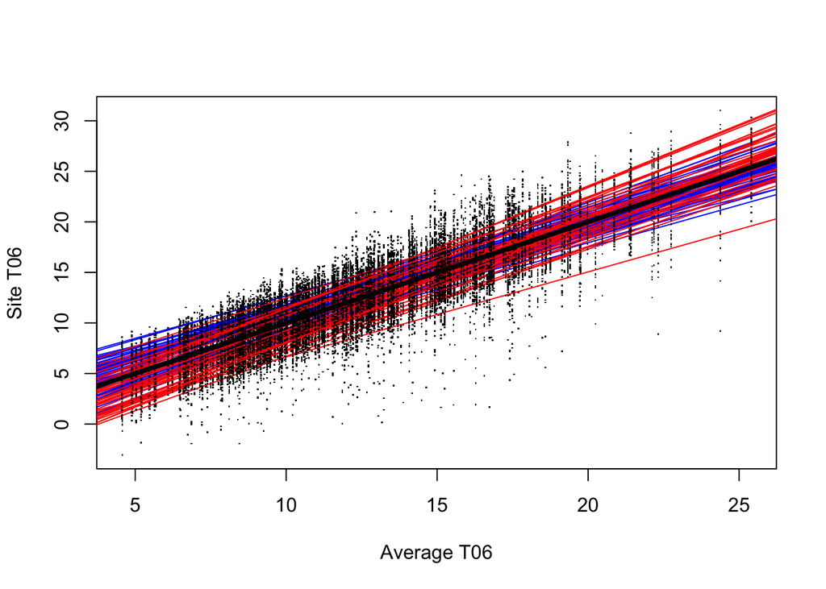

```r
var <- 'T06'
dw$y <- dw[,var]
dlySummary$x <- dlySummary[,var]

T_range <- range(dw$y,na.rm=T)
nSites <- length(meta$siteID)

N <- rep(NA,nSites)
inter <- rep(NA,nSites)
slp <- rep(NA,nSites)
r2 <- rep(NA,nSites)
Tmean <- rep(NA,nSites)
cpal <- c('blue','red')[as.factor(meta$domain)]

plot(dlySummary$x,dlySummary$x,ylim=c(T_range),type='n',xlab=paste('Average',var),ylab=paste('Site',var))

i=85
for (i in 1:nSites) {
    dws <- subset(dw,dw$siteID==meta$siteID[i])
    N[i] <- sum(complete.cases(cbind(dws$y,dlySummary$x)))
    if (N[i]>200) {
        points(dws$y~dlySummary$x,pch='.')
        fit <- lm(dws$y~dlySummary$x)
        abline(fit,col=cpal[i])
        inter[i] <- fit$coefficients[1]
        slp[i] <- fit$coefficients[2]
        r2[i] <- summary(fit)$r.squared
        Tmean[i] <- mean(dws$y,na.rm=T)
    }
}
abline(0,1,lwd=4)
```

```r
## For Tmin and Tmax, two sites had very anomolous slopes - these do need to be explained but for now they are removed to avoid outlier effects on subsequent analyses. These don't affect the T06 and T14 analyses.
meta[which(slp<0.5),]
```

```
##  [1] domain               siteID               logger
##  [4] UTM.east             UTM.north            LON_DD
##  [7] LAT_DD               elevation            slope_deg
## [10] aspect_deg           magn.true.aspect     use4Analyses
## [13] use4ClimateSummaries route                CollSeq
## [16] series               deployed.as          deployXssn
## [19] start.date           start.hour           end.date
## [22] end.hour             log.max.d            VegSurveyPlot
## [25] VegSurveyDate        distOnTransect       Orig.siteID
## <0 rows> (or 0-length row.names)
```

```r
# remove them
slp[which(slp<0.5)] <- NA
```

If these slopes were varying randomly around a single underlying value, one thing you would see is that slopes and intercepts would be negatively correlated, because a low slope will extrapolate to a high intercept. This is true in these data:

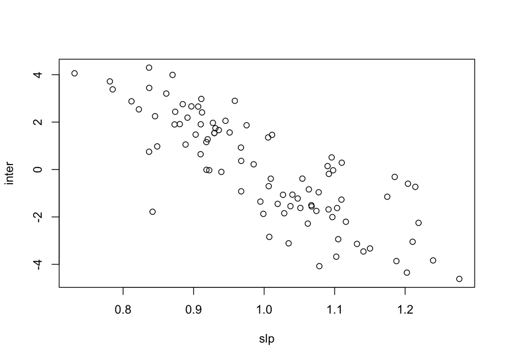

```r
plot(slp,inter)
```

However, if we can explain the variation in slopes, then even if there is some sampling error contributing to this, it means there is a systematic pattern on the landscape where some sites are more sensitive. As it turns out, slopes are higher on Table Mt. So Table Mt warms up more on warm days, and cools down more on cool days.

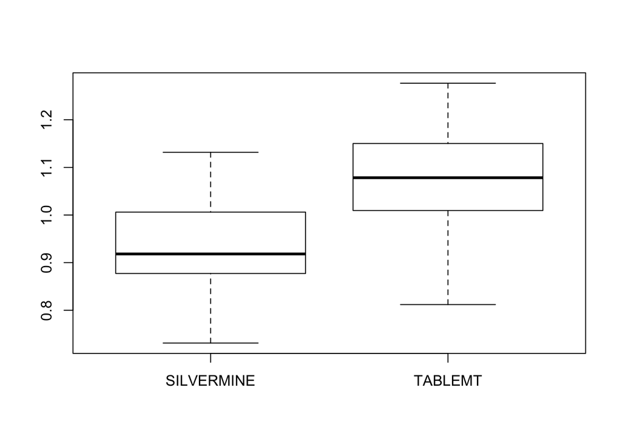

```r
boxplot(slp~meta$domain)
```

Perhaps this is an effect of elevation? Elevations are higher on the Table Mt. sites

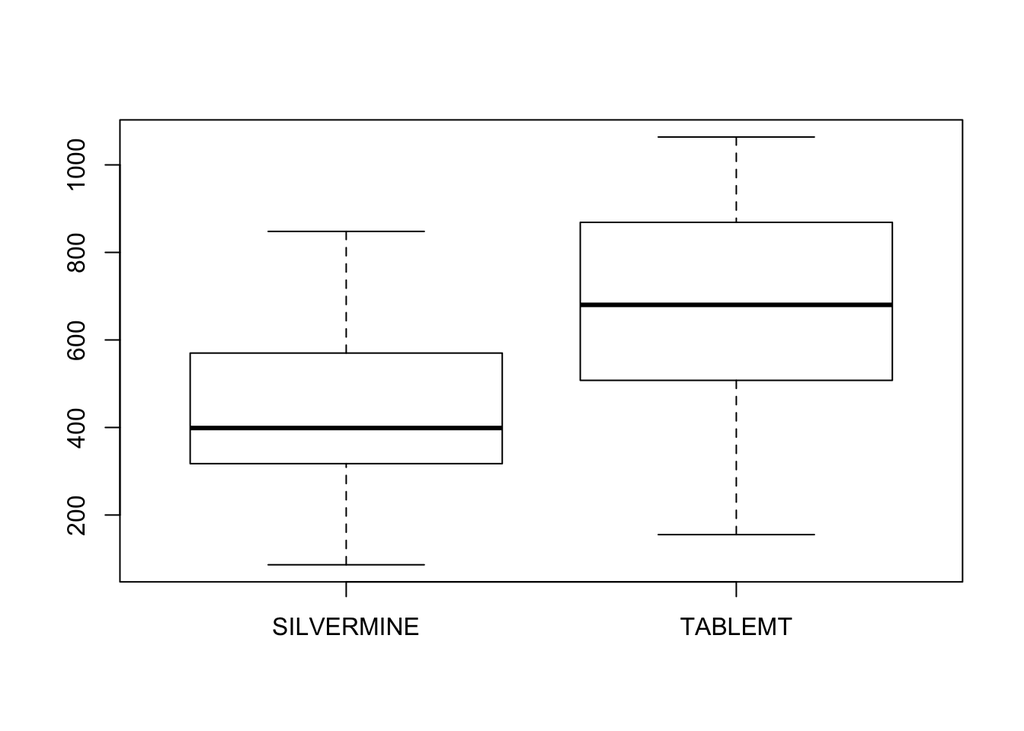

```r
boxplot(topo10$elevation~meta$domain)
```

There is a positive relationship of slope with elevation (red = Table Mt, blue = Silvermine). It’s actuallly tighter within Silvermine but found in both and across all sites:

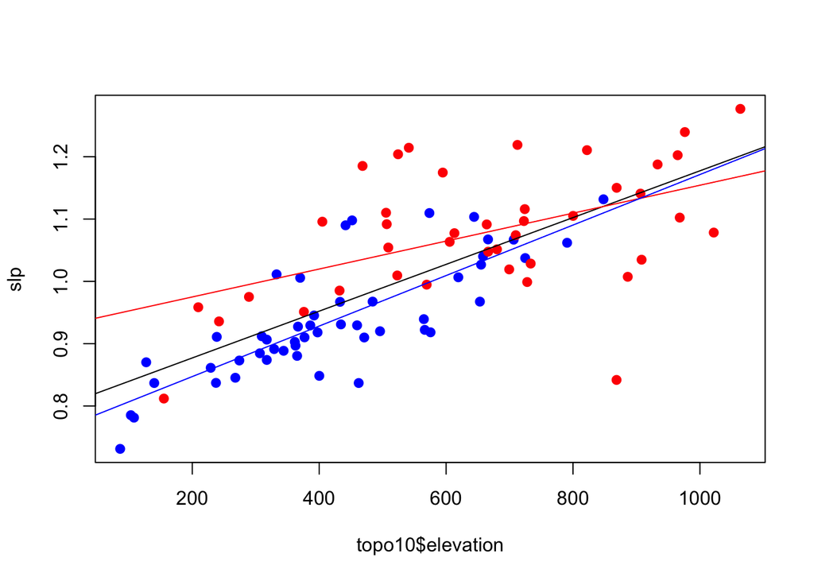

```r
plot(slp~topo10$elevation,col=cpal,pch=19)
abline(lm(slp~topo10$elevation))
ssel <- which(meta$domain=='TABLEMT')
abline(lm(slp[ssel]~topo10$elevation[ssel]),col='red')
ssel <- which(meta$domain=='SILVERMINE')
abline(lm(slp[ssel]~topo10$elevation[ssel]),col='blue')
```

So if elevation is the causal factor, the conclusion would be that montane sites fluctuate more than low elevation sites. This could be because the montane sites are more coupled to the free atmosphere which is fluctuating more, whereas low elevation are buffered. We could look at that by using the site at the cable car summit station as the reference, on the theory that it represents broader atmospheric conditions. This plot confirms that supposition as all other sites have slopes < 1 compared to the table mt summit station. But perhaps the underlying idea is wrong that the table is coupled with the atmosphere. On still hot days, the table can be very hot as it absorbs sunlight and not necessarily representative of ‘atmospheric’ conditions.

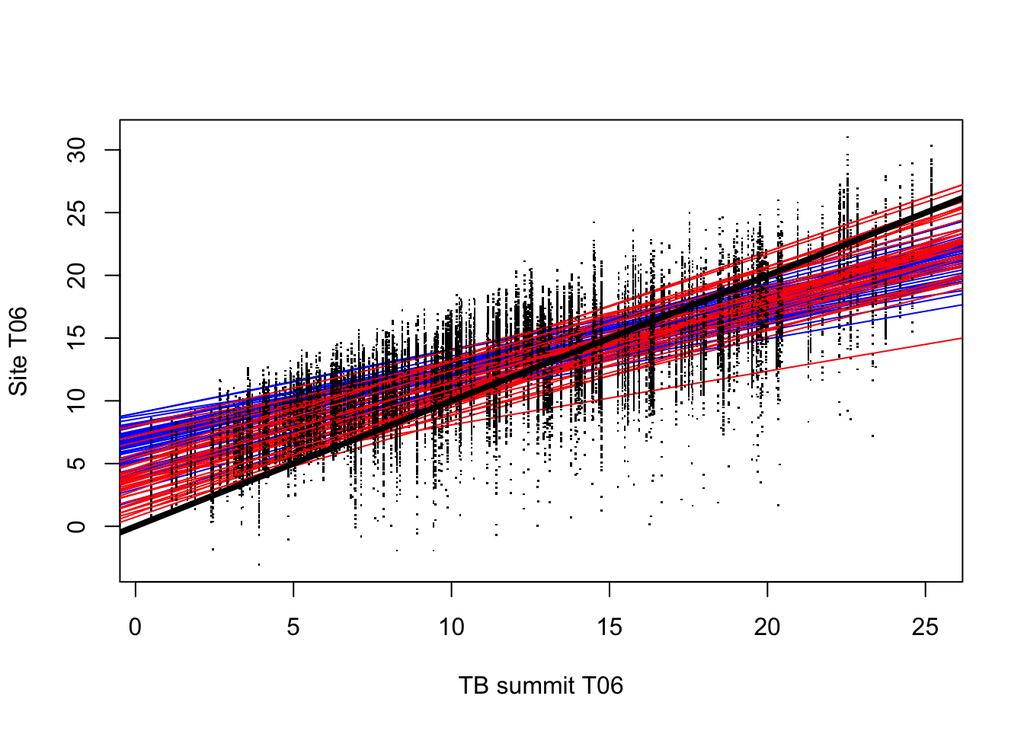

```r
plot(dw$y[dw$siteID=='TB.CWU'],dw$y[dw$siteID=='TB.CWU'],ylim=c(T_range),type='n',xlab=paste('TB summit',var),ylab=paste('Site',var))

i=85
for (i in 1:nSites) {
    dws <- subset(dw,dw$siteID==meta$siteID[i])
    N[i] <- sum(complete.cases(cbind(dws$y,dlySummary$x)))
    if (N[i]>200) {
        points(dws$y~dw$y[dw$siteID=='TB.CWU'],pch='.')
        fit <- lm(dws$y~dw$y[dw$siteID=='TB.CWU'])
        abline(fit,col=cpal[i])
    }
}
abline(0,1,lwd=4)
```

Okay, now we’re returning to the original analysis using the mean across all sites as the reference. Since Table Mt sites have higher slopes, it suggests that sites closer to the Atlantic ocean might have higher slopes. Confirmed, even for the sites on Silvermine.

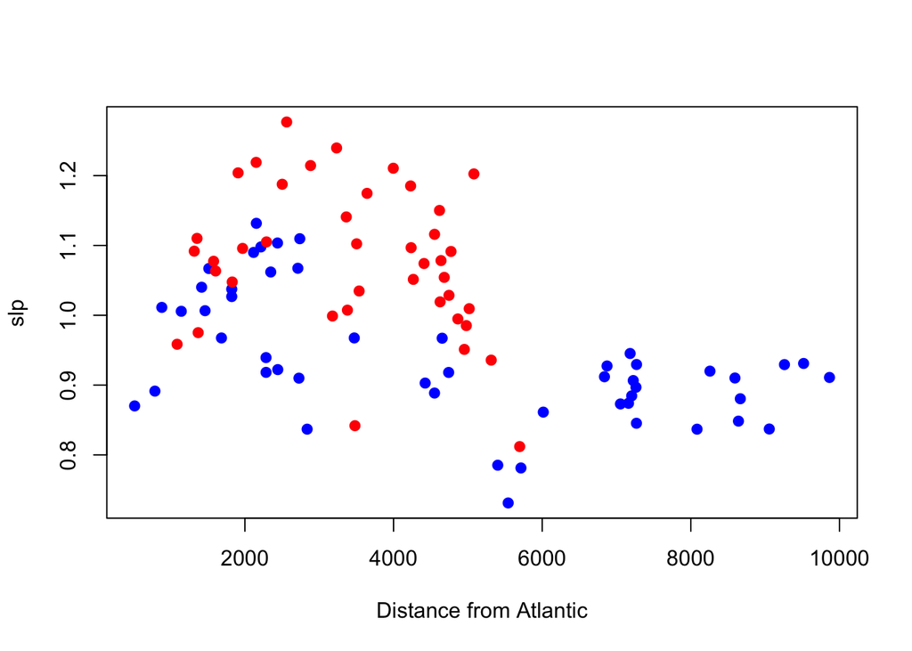

```r
plot(topo10$d2at,slp,col=cpal,pch=19,xlab='Distance from Atlantic')
```

My original hypothesis was that valley bottom sites might have steeper slopes - warmer on warm days and cooler on cool nights. Now, this it the T06 data so we should look at Tmax as well. But here are the relationships with TPI and PLOW values. Nothing doing, although a suggestion of higher slopes on hilltops (opposite of hypothesis).

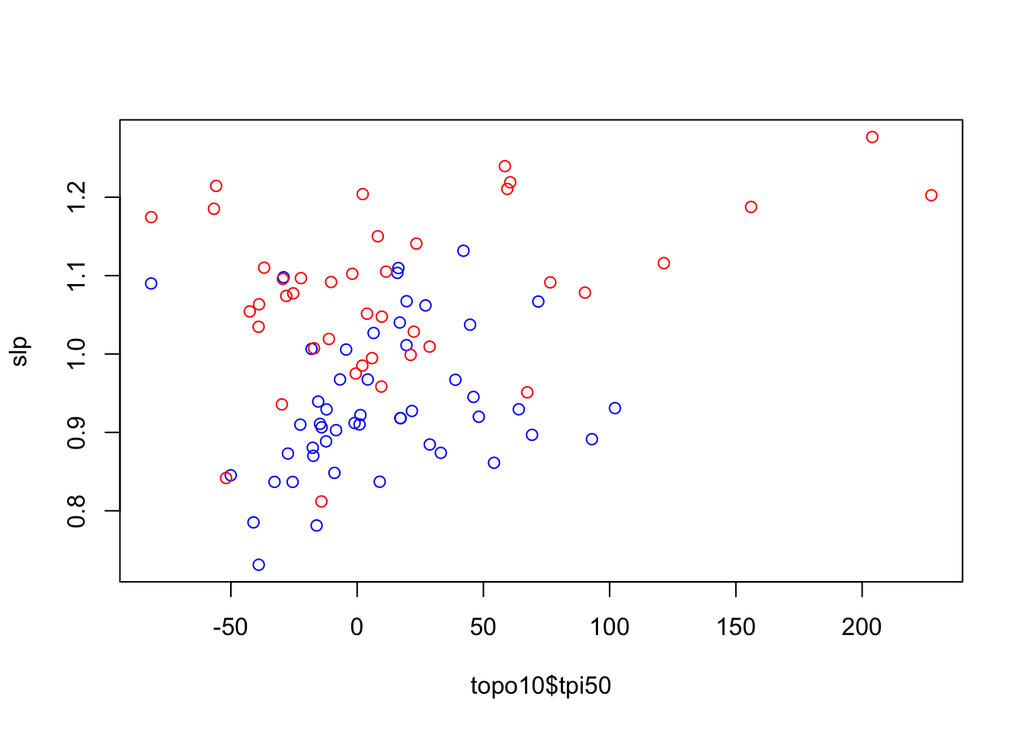

```r
plot(topo10$tpi50,slp,col=cpal)
```

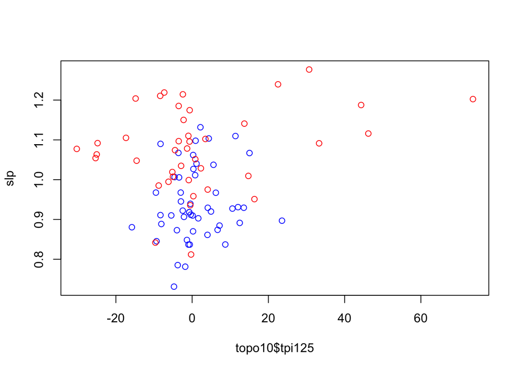

```r
plot(topo10$tpi125,slp,col=cpal)
```

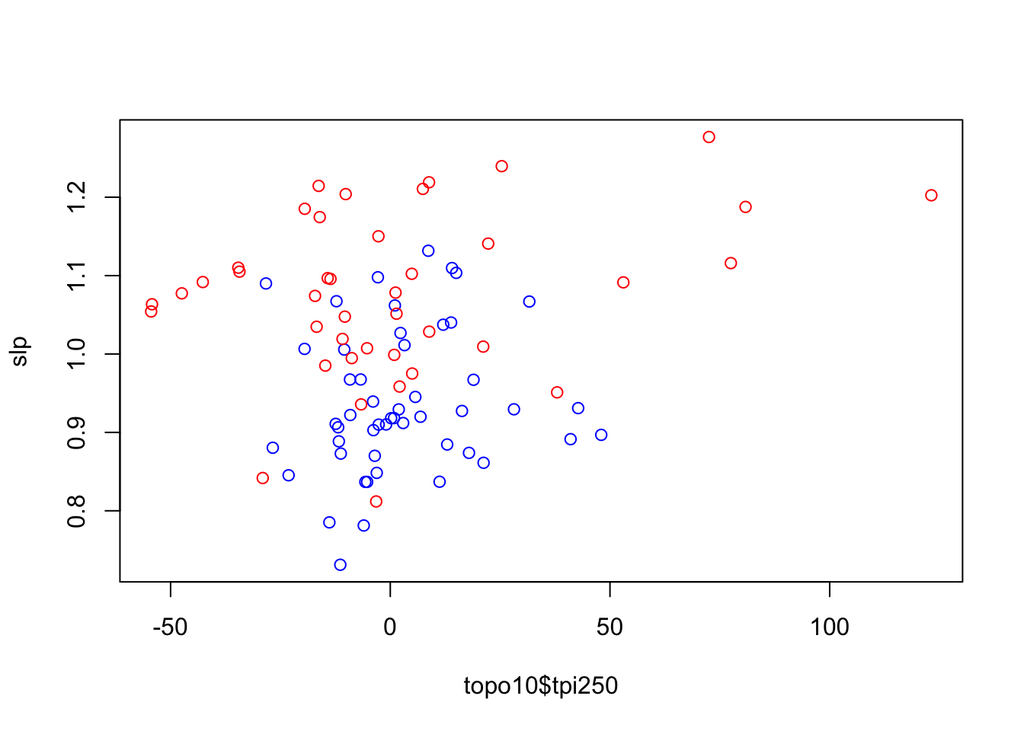

```r
plot(topo10$tpi250,slp,col=cpal)
```

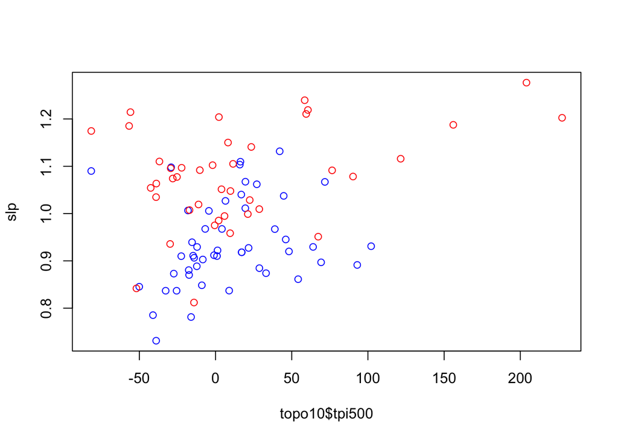

```r
plot(topo10$tpi500,slp,col=cpal)
```

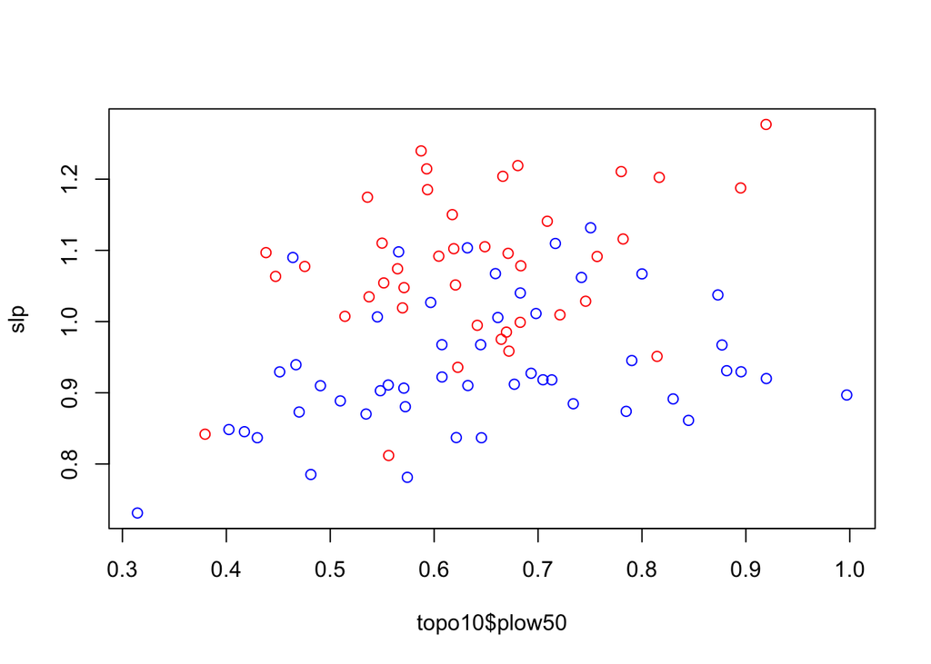

```r
plot(topo10$plow50,slp,col=cpal)
```

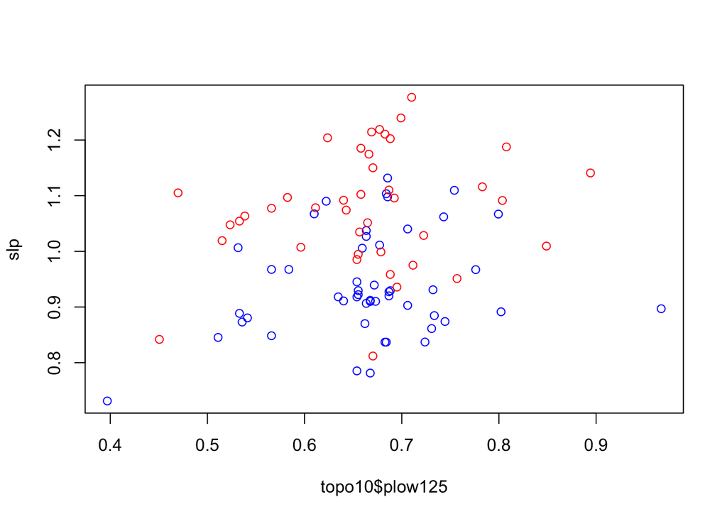

```r
plot(topo10$plow125,slp,col=cpal)
```

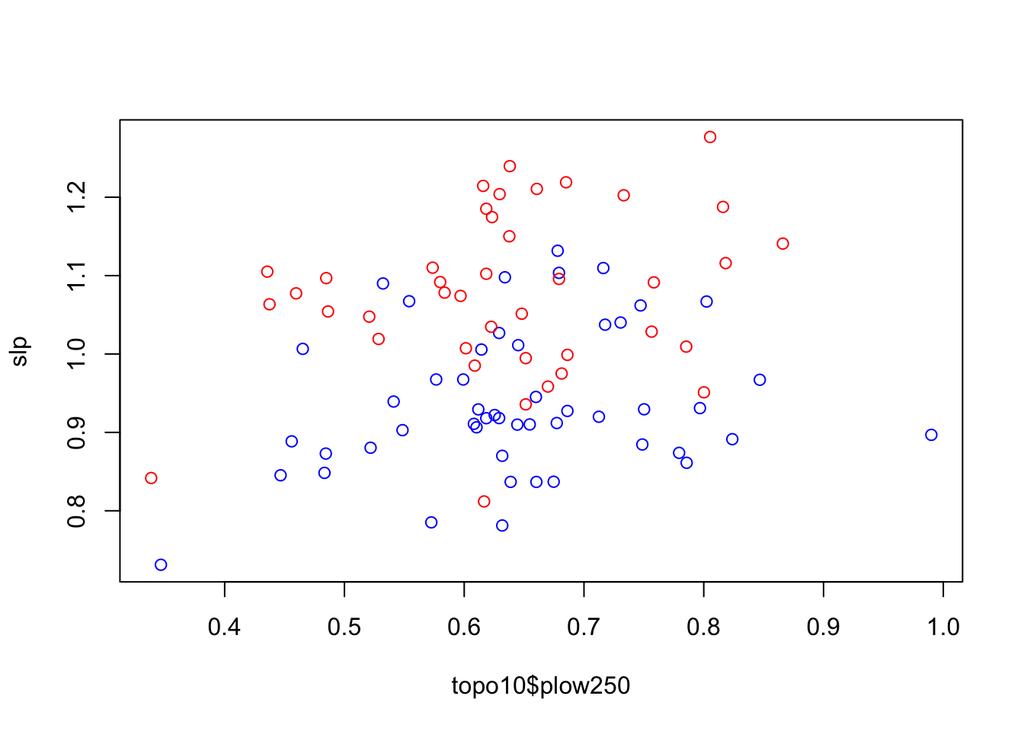

```r
plot(topo10$plow250,slp,col=cpal)
```

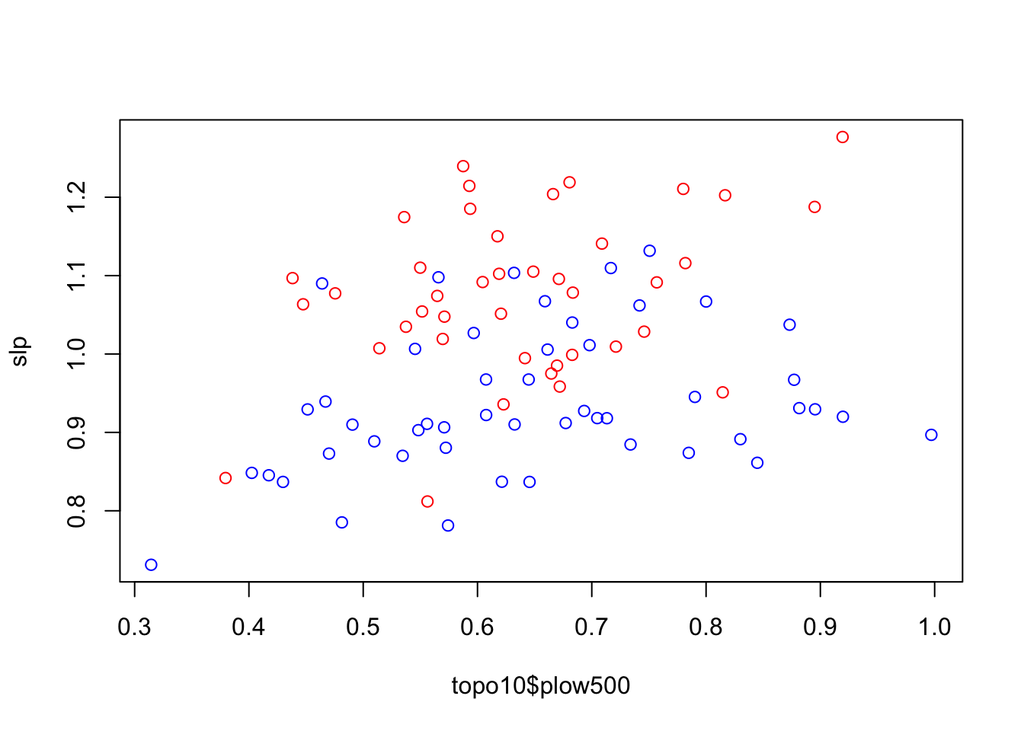

```r
plot(topo10$plow500,slp,col=cpal)
```

Finally, we can just do the glm to test for multivariate relationships. First check some pairwise relationships to avoid testing on colinear predictors. This analysis suggests a positive effect of elevation, a weak positive effect of solar exposure (north-facing slopes), and a positive effect of terrain slope (steeper terrain have higher slopes in T06) [apologies for using slope in two different senses here!].

```r
cor(cbind(topo10$elevation,Tmean,topo10$tpi125,topo10$thl0,topo10$slope,topo10$d2cs,topo10$at),use='pair')
```

```
##                        Tmean
##        1.0000000 -0.80577695  0.2670844 -0.25222693  0.2476412  0.16450136
## Tmean -0.8057770  1.00000000 -0.1267650  0.09859438  0.1914295 -0.31527207
##        0.2670844 -0.12676503  1.0000000 -0.16122335  0.1802139  0.20237925
##       -0.2522269  0.09859438 -0.1612234  1.00000000 -0.4959354 -0.04354384
##        0.2476412  0.19142949  0.1802139 -0.49593538  1.0000000 -0.06811910
##        0.1645014 -0.31527207  0.2023792 -0.04354384 -0.0681191  1.00000000
```

```r
fit <- glm(slp~elevation+tpi500+thl0+slope,data=topo10)
summary(fit)
```

```
##
## Call:
## glm(formula = slp ~ elevation + tpi500 + thl0 + slope, data = topo10)
##
## Deviance Residuals:
##       Min         1Q     Median         3Q        Max
## -0.222140  -0.042870   0.004188   0.036862   0.161705
##
## Coefficients:
##               Estimate Std. Error t value Pr(>|t|)
## (Intercept)  6.357e-01  4.632e-02  13.724  < 2e-16 ***
## elevation    3.361e-04  3.000e-05  11.201  < 2e-16 ***
## tpi500      -6.429e-05  1.355e-04  -0.474   0.6364
## thl0         9.809e-02  4.050e-02   2.422   0.0175 *
## slope        2.364e-01  2.863e-02   8.257  1.6e-12 ***
## ---
## Signif. codes:  0 '***' 0.001 '**' 0.01 '*' 0.05 '.' 0.1 ' ' 1
##
## (Dispersion parameter for gaussian family taken to be 0.003697124)
##
##     Null deviance: 1.28507  on 90  degrees of freedom
## Residual deviance: 0.31795  on 86  degrees of freedom
##   (5 observations deleted due to missingness)
## AIC: -244.51
##
## Number of Fisher Scoring iterations: 2
```

Now let’s do the analysis for T14 (early afternoon temperature) and just progress straight to the glm to see the results.

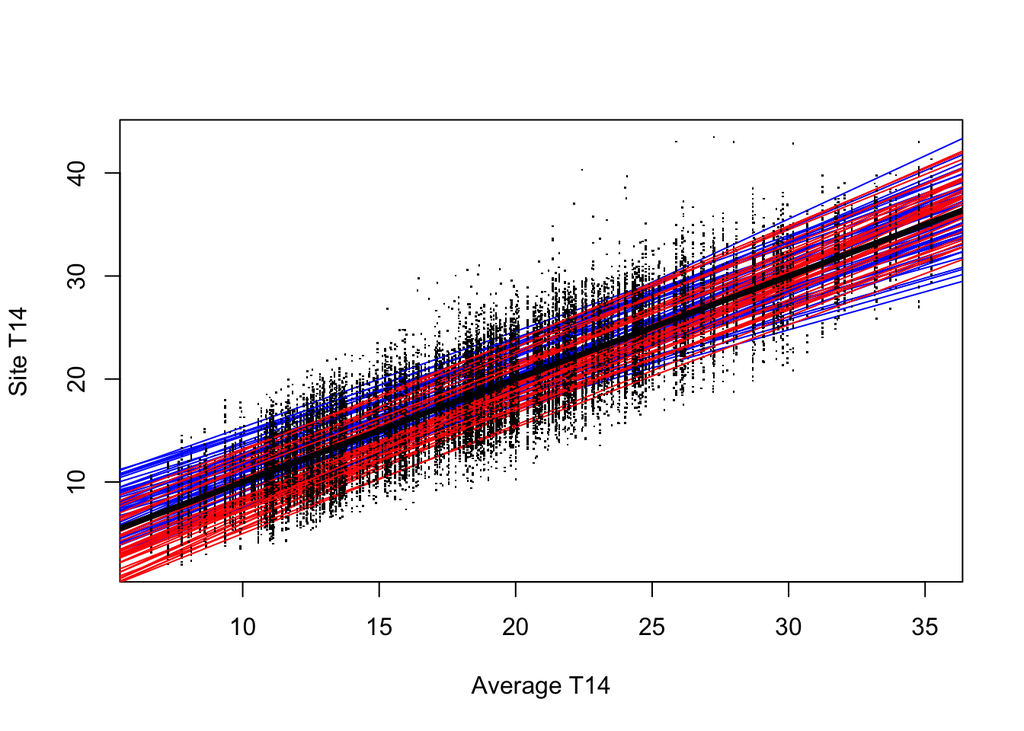

```r
var <- 'T14'
dw$y <- dw[,var]
dlySummary$x <- dlySummary[,var]

T_range <- range(dw$y,na.rm=T)
nSites <- length(meta$siteID)

N <- rep(NA,nSites)
inter <- rep(NA,nSites)
slp <- rep(NA,nSites)
r2 <- rep(NA,nSites)
Tmean <- rep(NA,nSites)
cpal <- c('blue','red')[as.factor(meta$domain)]

plot(dlySummary$x,dlySummary$x,ylim=c(T_range),type='n',xlab=paste('Average',var),ylab=paste('Site',var))

i=85
for (i in 1:nSites) {
    dws <- subset(dw,dw$siteID==meta$siteID[i])
    N[i] <- sum(complete.cases(cbind(dws$y,dlySummary$x)))
    if (N[i]>200) {
        points(dws$y~dlySummary$x,pch='.')
        fit <- lm(dws$y~dlySummary$x)
        abline(fit,col=cpal[i])
        inter[i] <- fit$coefficients[1]
        slp[i] <- fit$coefficients[2]
        r2[i] <- summary(fit)$r.squared
        Tmean[i] <- mean(dws$y,na.rm=T)
    }
}
abline(0,1,lwd=4)
```

```r
## For Tmin and Tmax, two sites had very anomolous slopes - these do need to be explained but for now they are removed to avoid outlier effects on subsequent analyses. These don't affect the T06 and T14 analyses.
meta[which(slp<0.5),]
```

```
##  [1] domain               siteID               logger
##  [4] UTM.east             UTM.north            LON_DD
##  [7] LAT_DD               elevation            slope_deg
## [10] aspect_deg           magn.true.aspect     use4Analyses
## [13] use4ClimateSummaries route                CollSeq
## [16] series               deployed.as          deployXssn
## [19] start.date           start.hour           end.date
## [22] end.hour             log.max.d            VegSurveyPlot
## [25] VegSurveyDate        distOnTransect       Orig.siteID
## <0 rows> (or 0-length row.names)
```

```r
# remove them
slp[which(slp<0.5)] <- NA
```

The glm gives an interesting and different result. Elevation is strong and positive again, with a similar coefficient, and then tpi500 is significant and negative. So this supports the view that valley bottoms have higher sensitivityfor T14, as hypothesized above.

```r
fit <- glm(slp~elevation+tpi500+thl0+slope,data=topo10)
summary(fit)
```

```
##
## Call:
## glm(formula = slp ~ elevation + tpi500 + thl0 + slope, data = topo10)
##
## Deviance Residuals:
##       Min         1Q     Median         3Q        Max
## -0.194365  -0.055840  -0.008304   0.065431   0.235286
##
## Coefficients:
##               Estimate Std. Error t value Pr(>|t|)
## (Intercept)  6.841e-01  7.338e-02   9.322 1.09e-14 ***
## elevation    3.778e-04  4.753e-05   7.948 6.72e-12 ***
## tpi500      -7.037e-04  2.147e-04  -3.278  0.00151 **
## thl0         1.243e-01  6.416e-02   1.937  0.05603 .
## slope        4.111e-02  4.535e-02   0.907  0.36719
## ---
## Signif. codes:  0 '***' 0.001 '**' 0.01 '*' 0.05 '.' 0.1 ' ' 1
##
## (Dispersion parameter for gaussian family taken to be 0.009279147)
##
##     Null deviance: 1.42713  on 90  degrees of freedom
## Residual deviance: 0.79801  on 86  degrees of freedom
##   (5 observations deleted due to missingness)
## AIC: -160.77
##
## Number of Fisher Scoring iterations: 2
```

Let’s have a look

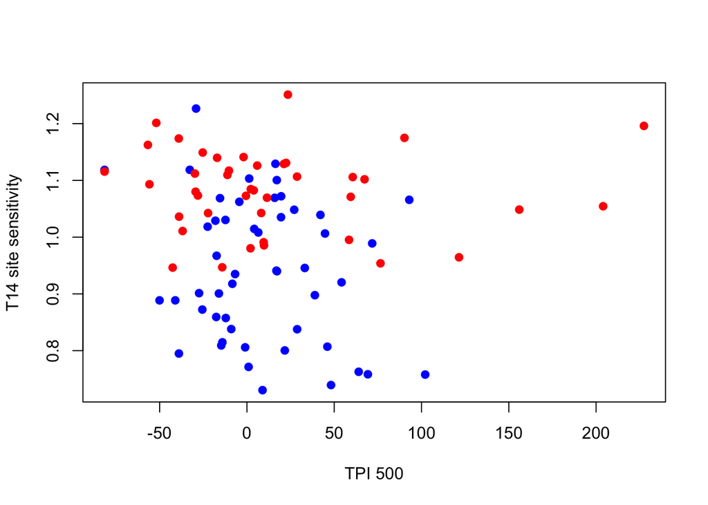

```r
plot(topo10$tpi500,slp,col=cpal,pch=19,xlab='TPI 500',ylab='T14 site sensitivity')
```

Extra code snippets:

```r
# plot(N,slope,col=cpal)
# plot(r2,slp,col=cpal)
# plot(Tmean,slp,col=cpal)
#
# plot(topo10$elevation,slp,col=cpal)
# plot(topo10$d2cs,slp,col=cpal)
# plot(topo10$d2fb,slp,col=cpal)
#
# plot(topo10$thl0,slp,col=cpal)
# plot(topo10$slope,slp,col=cpal)
#
# plot(topo10$elevation~topo10$d2at,col=cpal)
# plot(topo10$elevation~topo10$d2fb,col=cpal)
#
# cor(cbind(topo10$elevation,Tmean,topo10$tpi125,topo10$thl0,topo10$slope,topo10$d2cs,topo10$at),use='pair')
#
# fit <- lm(slp~elevation+tpi125+thl0+slope+d2cs,data=topo10)
# summary(fit)
# summary(fit)$r.squared
#
# fit <- glm(slp~elevation+tpi125+thl0+slope+d2at,data=topo10)
# summary(fit)
#
# fit <- glm(slp~meta$domain+elevation+tpi125+thl0+slope,data=topo10)
# summary(fit)
# var
```